# Assignment 2:Exploring ggplot2 Geoms Functions

Alain Tresor Uwineza

2026-10-31

# Setup

We load **ggplot2** and read the dataset `store_sales.csv`.

The data contains 60 rows: daily sales for 3 stores (North, South, Central) over 20 days. Columns: `day`, `date`, `store`, `category`, `customers`, `units_sold`, `avg_price`, `revenue`, `rating`.

```r
# Install once if the package is not already installed:
# install.package("ggplot2")

library(ggplot2)

sales <- read.csv("store_sales.csv")
sales$date <- as.Date(sales$date)

head(sales)
```

```
##   day       date   store    category customers units_sold avg_price revenue
## 1   1 2026-09-01   North Electronics        91         89    104.19 9272.91
## 2   1 2026-09-01   South Electronics        61         53     73.96 3919.88
## 3   1 2026-09-01 Central Electronics        72         97     85.17 8261.49
## 4   2 2026-09-02   North        Toys        58         46     26.12 1201.52
## 5   2 2026-09-02   South        Toys        61         95     16.73 1589.35
## 6   2 2026-09-02 Central Electronics        88         94     75.87 7131.78
##   rating
## 1    4.3
## 2    3.7
## 3    4.2
## 4    3.8
## 5    4.0
## 6    4.7
```

```r
str(sales)
```

```
## 'data.frame':    60 obs. of  9 variables:
##  $ day       : int  1 1 1 2 2 2 3 3 3 4 ...
##  $ date      : Date, format: "2026-09-01" "2026-09-01" ...
##  $ store     : chr  "North" "South" "Central" "North" ...
##  $ category  : chr  "Electronics" "Electronics" "Electronics" "Toys" ...
##  $ customers : int  91 61 72 58 61 88 80 74 115 94 ...
##  $ units_sold: int  89 53 97 46 95 94 126 110 118 109 ...
##  $ avg_price : num  104.2 74 85.2 26.1 16.7 ...
##  $ revenue   : num  9273 3920 8261 1202 1589 ...
##  $ rating    : num  4.3 3.7 4.2 3.8 4 4.7 3.7 3.3 4.5 3.9 ...
```

# 1. geom_bar()

**Function name:** `geom_bar()`

**Short description:** Draws a bar chart where the bar height is the **count** of rows in each category (it uses `stat = "count"` by default).

**What we are doing with it:** Counting how many sales records belong to each product category, split by store.

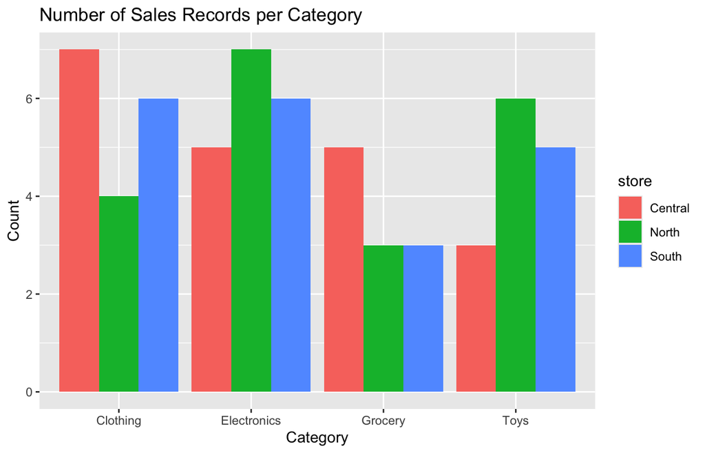

```r
ggplot(sales, aes(x = category, fill = store)) +
  geom_bar(position = "dodge") +
  labs(title = "Number of Sales Records per Category",
       x = "Category", y = "Count")
```

# 2. geom_boxplot()

**Function name:** `geom_boxplot()`

**Short description:** Shows the distribution of a numeric variable using the median, quartiles (the box), whiskers, and outliers.

**What we are doing with it:** Comparing the spread of daily customer numbers across the three stores.

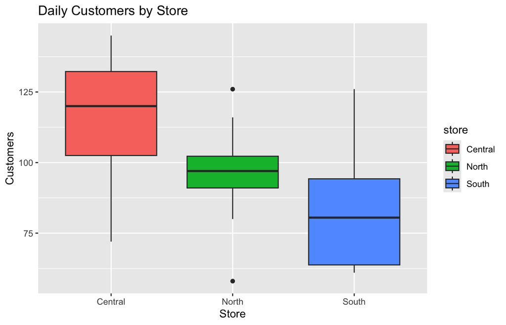

```r
ggplot(sales, aes(x = store, y = customers, fill = store)) +
  geom_boxplot() +
  labs(title = "Daily Customers by Store",
       x = "Store", y = "Customers")
```

# 3. geom_density()

**Function name:** `geom_density()`

**Short description:** Draws a smoothed curve (kernel density estimate) of a numeric variable’s distribution — like a smooth histogram.

**What we are doing with it:** Comparing the distribution of customer ratings for each store.

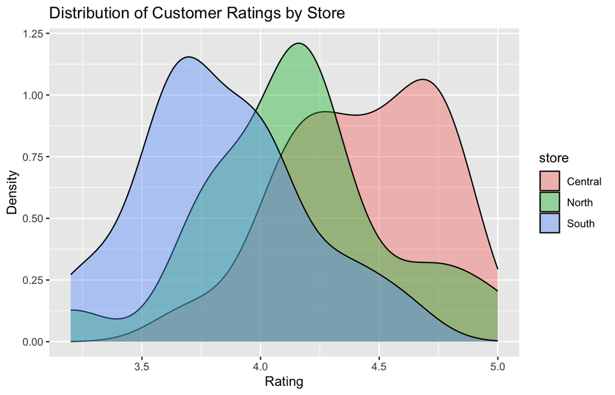

```r
ggplot(sales, aes(x = rating, fill = store)) +
  geom_density(alpha = 0.4) +
  labs(title = "Distribution of Customer Ratings by Store",
       x = "Rating", y = "Density")
```

# 4. geom_histogram()

**Function name:** `geom_histogram()`

**Short description:** Splits a numeric variable into bins and draws bars showing how many values fall into each bin.

**What we are doing with it:** Looking at how the number of units sold per day is distributed.

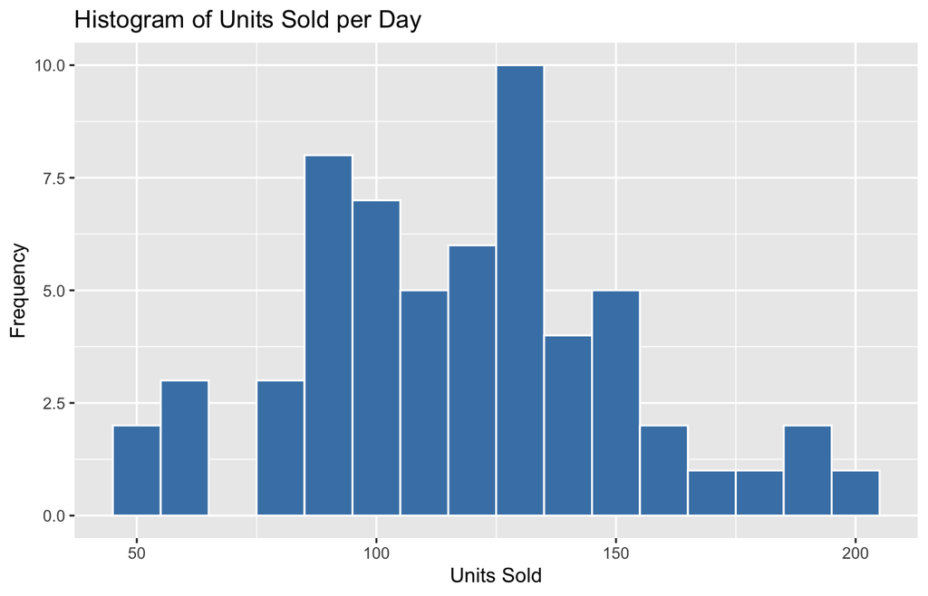

```r
ggplot(sales, aes(x = units_sold)) +
  geom_histogram(binwidth = 10, fill = "steelblue", color = "white") +
  labs(title = "Histogram of Units Sold per Day",
       x = "Units Sold", y = "Frequency")
```

# 5. geom_hline()

**Function name:** `geom_hline()`

**Short description:** Adds a **horizontal** reference line at a given y value (`yintercept`).

**What we are doing with it:** Plotting daily customers and adding a dashed line at the overall average, so we can see which days are above or below average.

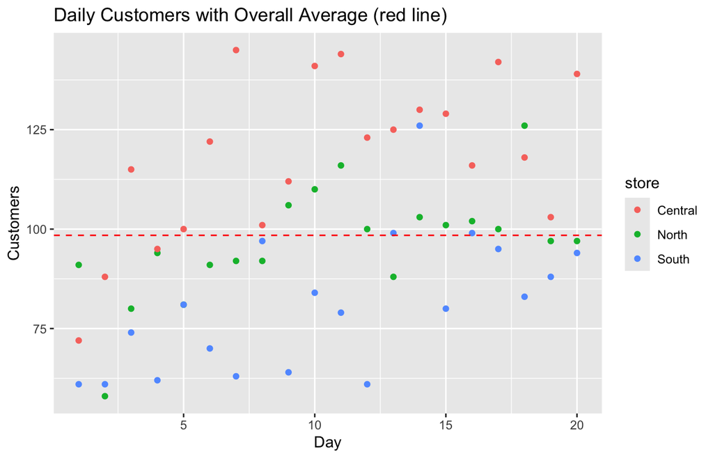

```r
avg_customers <- mean(sales$customers)

ggplot(sales, aes(x = day, y = customers, color = store)) +
  geom_point() +
  geom_hline(yintercept = avg_customers, linetype = "dashed", color = "red") +
  labs(title = "Daily Customers with Overall Average (red line)",
       x = "Day", y = "Customers")
```

# 6. geom_jitter()

**Function name:** `geom_jitter()`

**Short description:** A scatter plot where points get a small random offset, so overlapping points become visible.

**What we are doing with it:** Showing every individual rating per store without points stacking on top of each other.

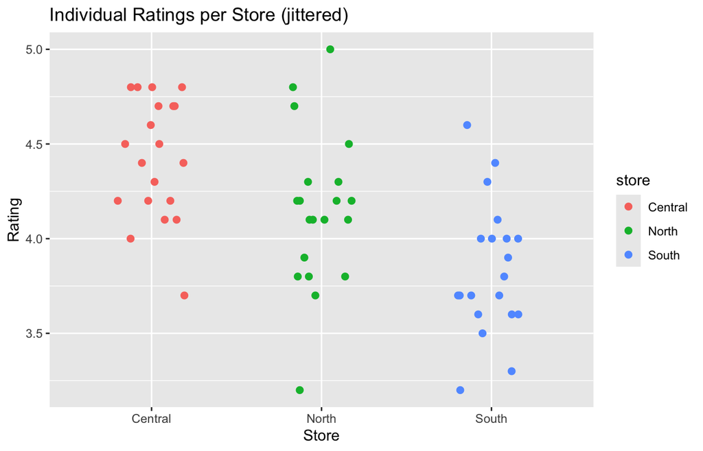

```r
ggplot(sales, aes(x = store, y = rating, color = store)) +
  geom_jitter(width = 0.2, height = 0, size = 2) +
  labs(title = "Individual Ratings per Store (jittered)",
       x = "Store", y = "Rating")
```

# 7. geom_line()

**Function name:** `geom_line()`

**Short description:** Connects data points with lines in order of the x variable — ideal for trends over time.

**What we are doing with it:** Showing how the number of customers changes over the 20 days for each store.

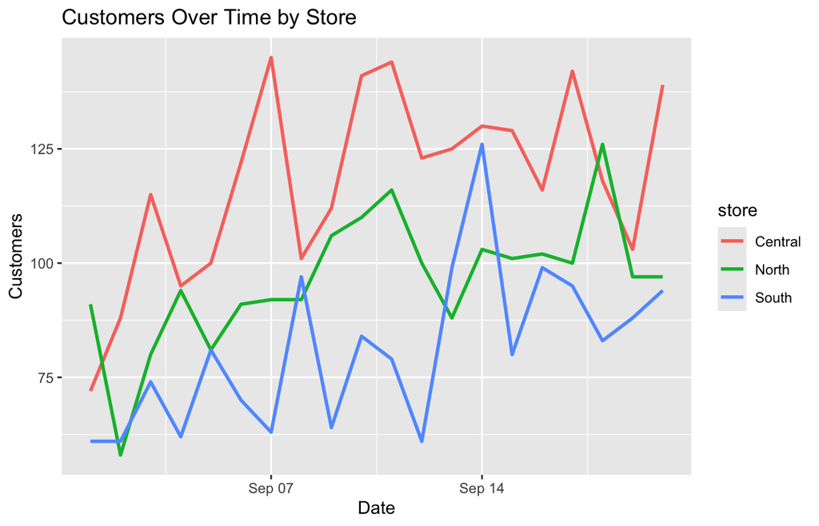

```r
ggplot(sales, aes(x = date, y = customers, color = store)) +
  geom_line(linewidth = 1) +
  labs(title = "Customers Over Time by Store",
       x = "Date", y = "Customers")
```

# 8. geom_point()

**Function name:** `geom_point()`

**Short description:** Creates a scatter plot — one point per row, positioned by x and y.

**What we are doing with it:** Exploring the relationship between number of customers and units sold.

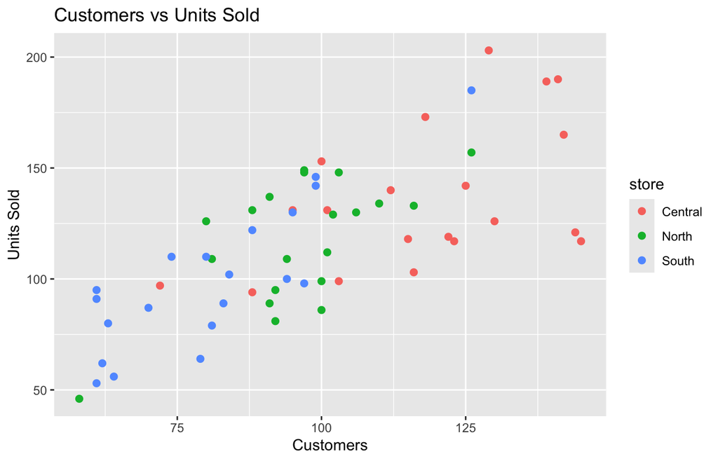

```r
ggplot(sales, aes(x = customers, y = units_sold, color = store)) +
  geom_point(size = 2) +
  labs(title = "Customers vs Units Sold",
       x = "Customers", y = "Units Sold")
```

# 9. geom_rug()

**Function name:** `geom_rug()`

**Short description:** Adds small tick marks along the axes showing where each individual data value lies (a 1-D view of the data).

**What we are doing with it:** Adding rug marks to the customers vs units scatter plot to show the distribution of each variable along its axis.

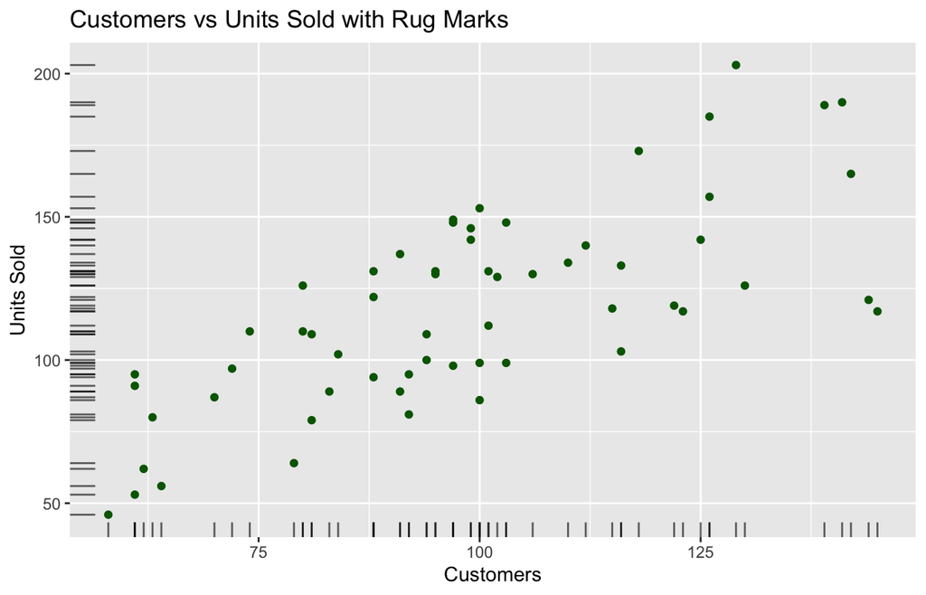

```r
ggplot(sales, aes(x = customers, y = units_sold)) +
  geom_point(color = "darkgreen") +
  geom_rug(alpha = 0.6) +
  labs(title = "Customers vs Units Sold with Rug Marks",
       x = "Customers", y = "Units Sold")
```

# 10. geom_smooth()

**Function name:** `geom_smooth()`

**Short description:** Adds a fitted trend line (e.g. linear regression with `method = "lm"`) with a shaded confidence band.

**What we are doing with it:** Fitting a linear trend to see whether more customers leads to more units sold.

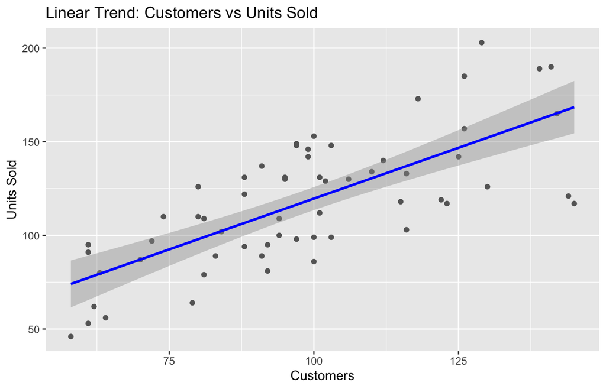

```r
ggplot(sales, aes(x = customers, y = units_sold)) +
  geom_point(color = "gray40") +
  geom_smooth(method = "lm", color = "blue") +
  labs(title = "Linear Trend: Customers vs Units Sold",
       x = "Customers", y = "Units Sold")
```

# 11. geom_text()

**Function name:** `geom_text()`

**Short description:** Places text labels on the plot at given x/y positions.

**What we are doing with it:** Labeling each bar with the total revenue of each store.

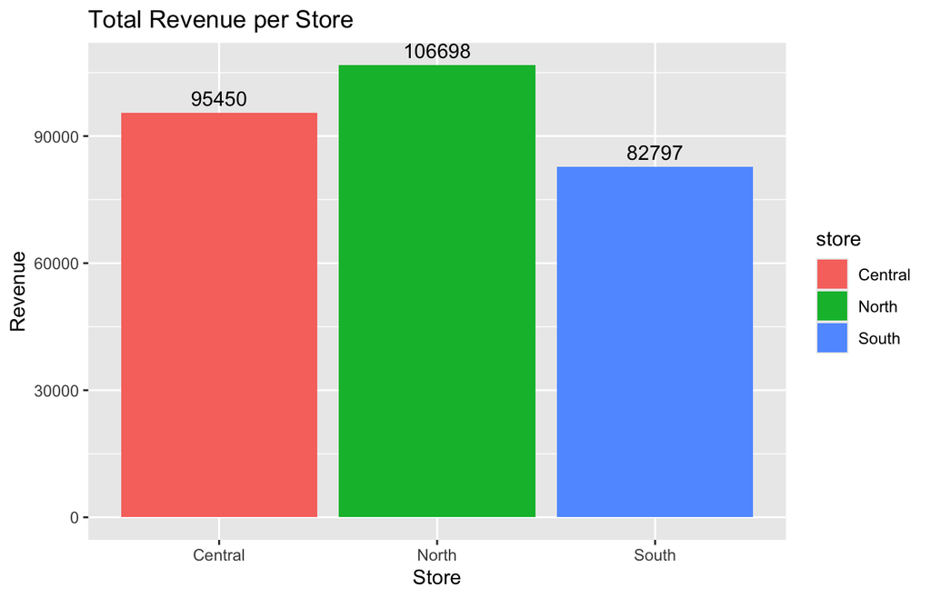

```r
store_revenue <- aggregate(revenue ~ store, data = sales, FUN = sum)

ggplot(store_revenue, aes(x = store, y = revenue, fill = store)) +
  geom_col() +
  geom_text(aes(label = round(revenue)), vjust = -0.5) +
  labs(title = "Total Revenue per Store",
       x = "Store", y = "Revenue")
```

# 12. geom_violin()

**Function name:** `geom_violin()`

**Short description:** Combines a boxplot idea with a density curve — the width of the “violin” shows where values are concentrated.

**What we are doing with it:** Comparing the shape of the units-sold distribution in each store.

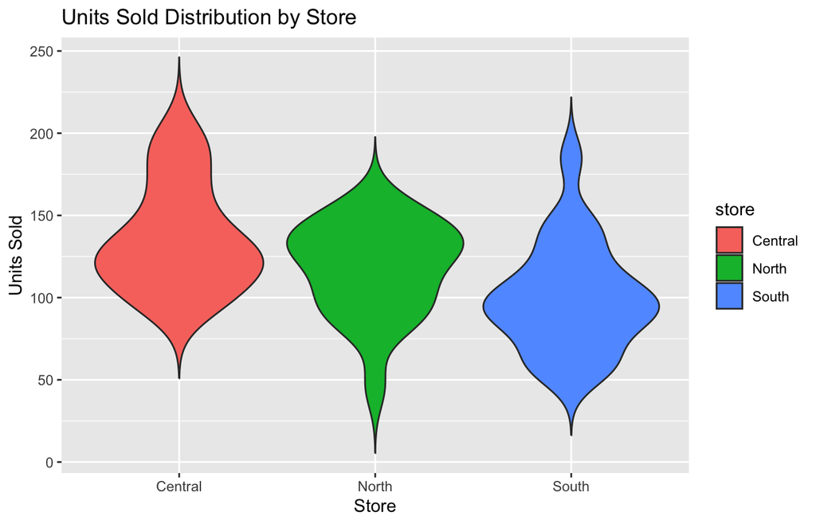

```r
ggplot(sales, aes(x = store, y = units_sold, fill = store)) +
  geom_violin(trim = FALSE) +
  labs(title = "Units Sold Distribution by Store",
       x = "Store", y = "Units Sold")
```

# 13. geom_vline()

**Function name:** `geom_vline()`

**Short description:** Adds a **vertical** reference line at a given x value (`xintercept`).

**What we are doing with it:** Drawing a histogram of ratings and marking the average rating with a vertical line.

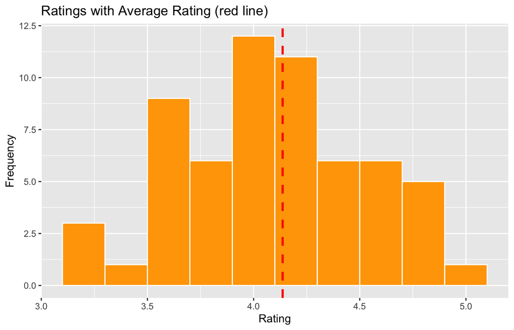

```r
avg_rating <- mean(sales$rating)

ggplot(sales, aes(x = rating)) +
  geom_histogram(binwidth = 0.2, fill = "orange", color = "white") +
  geom_vline(xintercept = avg_rating, color = "red", linewidth = 1, linetype = "dashed") +
  labs(title = "Ratings with Average Rating (red line)",
       x = "Rating", y = "Frequency")
```

# Summary

| Function | Main use |
| --- | --- |
| `geom_bar()` | Count of categories |
| `geom_boxplot()` | Distribution summary (median, quartiles) |
| `geom_density()` | Smooth distribution curve |
| `geom_histogram()` | Binned distribution |
| `geom_hline()` | Horizontal reference line |
| `geom_jitter()` | Scatter with random offset |
| `geom_line()` | Trends over time |
| `geom_point()` | Scatter plot |
| `geom_rug()` | Axis tick marks for each value |
| `geom_smooth()` | Trend / regression line |
| `geom_text()` | Text labels |
| `geom_violin()` | Distribution shape by group |
| `geom_vline()` | Vertical reference line |